# Electricity

### Coulomb Law

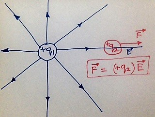

Coulomb law between two charges (at rest):$\text{Magnitude of Force, } \boxed{F = k {{q_1 q_2}\over{r^2}}}$

A better way to think: Force on charge $q_2$ due to electric field from $q_1$ is: $\boxed{\vec{F} = q_2 \vec{E}\;\;}$ , where $\boxed{\vec{E} = k{q_1\over{r^2}}}$

$\vec{E}$ is radially outward for positive charge, $\vec{q_1}$

## Question

```
A charged sphere has both a gravitational field around it. The diagram represents the field around such sphere.
Which field could this diagram represent?

  (A) both electrical and gravitational field

  (B) electric but not gravitational

  (C) gravitational but not electric

  (D) neither electric nor gravitational
```

## Hint

```
1. gravitational fields have only lines pointing inwards because the force is attractive.
2. for positive charge the electic field lines are pointing outwards and for negative charge the electric fields point inwards
```

## Answer

```
Answer is (b) as positive charge can only have electric field lines going outward.
```

### Charge movement - work done

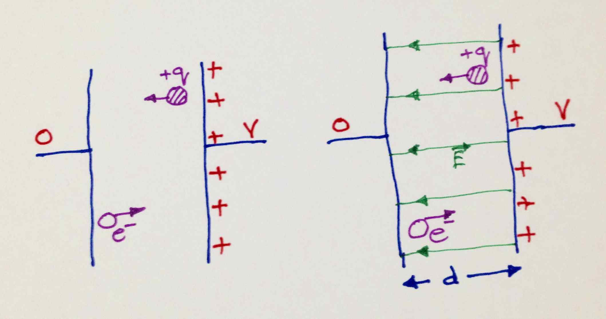

(The image shows a positive charge and electron between two parallel plates having potential difference of $V$. Two figures are same, Right figure shows the Electic Field)

$\boxed{\text{Energy gained (or work done)} = qV \;\;\;}$

$q$ is the charge, V is the Potential difference (Volt). The charge, $q$ moves from one potential to another potential with potential difference of $V$

$\boxed{\text{Energry gained (or work done)} = q E d \;\;\;}$

$q$ is the charge travelling in constant Electric field $E$ through a distance $d$

$\boxed{\text{Potential is scalar}\;\;}$ and simple potential difference between two points can be taken to define Voltage. When charge particle travel between the two points, the energy gained is $q V$

#### *Dimensional relationship between Electric field $E$ and $V$is:*

$E={V\over{L}}$

Always confirm dimensional relationship through any simple examples, such as:

Coloumb law of force between two charges: $\vec{F} = k {q_1 q_2\over{r^2}} \equiv q_1 \vec{E}$

Potential Energry due to charge: $P.E. = k {q_1 q_2\over{r}} \equiv q_1 V$

Potential has only one $r$ at the bottom and E has $r^2$ at the bottom. Therefore $V = E\times Length$